# Hassan01495449_CW2_final_run

### Task 1.1.2

I will now train the MLP as in 1.1.1 but now changing the learning rate to: (i) $10^{-5}$ and (ii) $10^{-1}.$ As in 1.1.1, i will again plot the loss and accuracies of the MLP as a function of the number of epochs for both the training and test sets, for these two values of the learning rates.

```python
dnn = MLP(sizes=layers, epochs = epoch, l_rate = 0.00001)
accuracy3, loss3 = dnn.train(x_train, y_train, x_train, y_train)
```

```python
dnn = MLP(sizes=layers, epochs = epoch, l_rate = 0.00001)
accuracy4, loss4 = dnn.train(x_train, y_train, x_test, y_test)
```

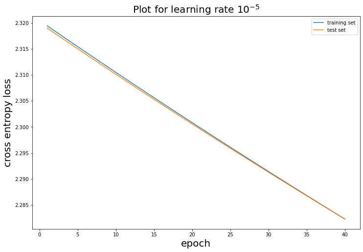

```python
plt.figure(figsize=(12,8))
plt.plot(epochs_list_40, loss3, label = 'training set')
plt.plot(epochs_list_40, loss4, label = 'test set')
plt.ylabel('cross entropy loss', size=20)
plt.xlabel('epoch', size=20)
plt.title('Plot for learning rate $10^{-5}$', size=20)
plt.legend()
plt.show()
```

[figure not shown]

```python
plt.figure(figsize=(12,8))
plt.plot(epochs_list_40, accuracy3, label = 'training set')
plt.plot(epochs_list_40, accuracy4, label = 'test set')
plt.ylabel('accuracy', size=20)
plt.xlabel('epoch', size=20)
plt.title('Plot for learning rate $10^{-3}$', size=20)
plt.legend()
plt.show()
```

```python
dnn = MLP(sizes=layers, epochs = epoch, l_rate = 0.1)
accuracy5, loss5 = dnn.train(x_train, y_train, x_train, y_train)
```

```python
dnn = MLP(sizes=layers, epochs = epoch, l_rate = 0.1)
accuracy6, loss6 = dnn.train(x_train, y_train, x_test, y_test)
```

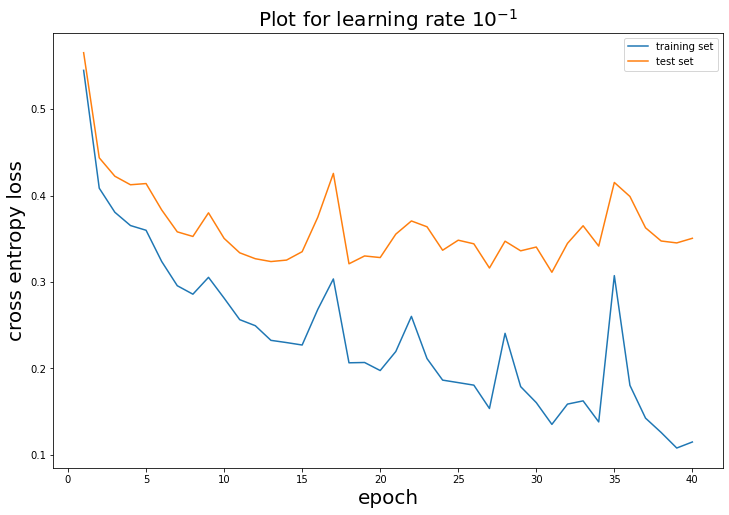

```python
plt.figure(figsize=(12,8))
plt.plot(epochs_list_40, loss5, label = 'training set')
plt.plot(epochs_list_40, loss6, label = 'test set')
plt.ylabel('cross entropy loss', size=20)
plt.xlabel('epoch', size=20)
plt.title('Plot for learning rate $10^{-1}$', size=20)
plt.legend()
plt.show()
```

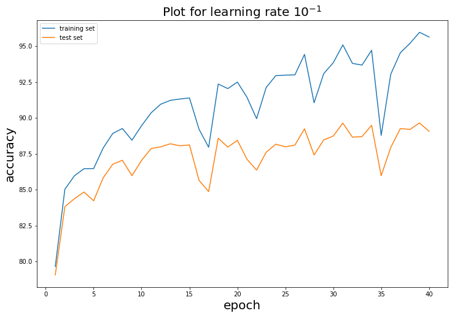

```python
plt.figure(figsize=(12,8))
plt.plot(epochs_list_40, accuracy5, label = 'training set')
plt.plot(epochs_list_40, accuracy6, label = 'test set')
plt.ylabel('accuracy', size=20)
plt.xlabel('epoch', size=20)
plt.title('Plot for learning rate $10^{-1}$', size=20)
plt.legend()
plt.show()
```

For the learning rate of 0.1, the loss and accuracy don't converge for training and test sets as we increase the number of epochs. The model is overfitting to the training data. Hence this learning rate is too high.

For the learning rate of $10^{-5}$ is too low, the accuracy of the model on very low and the loss is high and decreases linearly with the number of epochs. Although the loss and accuracy of the model don't converge for training and test sets, I believe this is because 40 epochs are not large enough for the model to converge for such a small learning rate.

The best out of the three learning rates tried was $10^{-3}$ as implemented in Task 1.1.1. This learning rate leads to a low cost (decreases polynomially, very fast to begin and then starts to level off) and high accuracy (increases polynomially, very fast to begin and then starts to level off) as the number of epochs increases. The accuracy and loss do also converge for training and test sets.

### Task 1.1.3

I will now train the neural network defined in 1.1.1 for 80 epochs and compare model performance (loss and accuracy on both the training and test sets) to the one achieved by only training for 40 epochs.

```python
epoch = 80
epochs_list_80 = list(range(1, epoch+1))
dnn = MLP(sizes=layers, epochs = epoch, l_rate = 0.001)
accuracy7, loss7 = dnn.train(x_train, y_train, x_train, y_train)
```

```python
dnn = MLP(sizes=layers, epochs = epoch, l_rate = 0.001)
accuracy8, loss8 = dnn.train(x_train, y_train, x_test, y_test)
```

[figure not shown]

```python
plt.figure(figsize=(12,8))
plt.plot(epochs_list_80, loss7, label = 'training set')
plt.plot(epochs_list_80, loss8, label = 'test set')
plt.ylabel('cross entropy loss', size=20)
plt.xlabel('epoch', size=20)
plt.title('Plot of CNN optimal dropout for 80 epochs with learning rate $10^{-3}$', size=20)
plt.legend()
plt.show()
```

[figure not shown]

```python
plt.figure(figsize=(12,8))
plt.plot(epochs_list_80, accuracy7, label = 'training set')
plt.plot(epochs_list_80, accuracy8, label = 'test set')
plt.ylabel('accuracy', size=20)
plt.xlabel('epoch', size=20)
plt.title('Plot of CNN optimal dropout for 80 epochs with learning rate $10^{-3}$', size=20)
plt.legend()
plt.show()
```

Increasing the number of epochs from 40 to 80 increased the accuracy of the model and decreased the loss. The loss didn't decrease significantly after 40 epochs. I think after 50 epochs the slight increase in accuracy and decrease in loss is not worth a balance with the increase in computation time.

## 1.2 Convolutional neural network (CNN) ^

### Task 1.2.1

Now using tensorflow, I will implement a convolutional neural network (CNN).

```python
from tensorflow.keras.models import Sequential
from tensorflow.keras.layers import Flatten, Conv2D, Dense, MaxPooling2D, Dropout
from tensorflow.keras.optimizers import SGD
keras = tf.keras
```

```python
(x_train, y_train), (x_test, y_test) = tf.keras.datasets.fashion_mnist.load_data()
x_train = x_train.astype('float32') / 255
x_test = x_test.astype('float32') / 255

# Reshaping each image into dimensions (1, 28, 28, 1)
x_train = x_train.reshape((x_train.shape + (1,)))
x_test = x_test.reshape((x_test.shape + (1,)))
```

My network has a input layer, 5 hidden layers in total (of which the first 4 are convolutional layers and the last is a fully-connected layer), followed by the output layer with 10 neurons (one for each class).Regarding the hidden layers: all convolutional layers apply 3 ✕ 3 filters, but the first two use 8 feature maps and the last two use 16 feature maps (also called ‘channels’). The last convolutional layer is followed by a 2 ✕ 2 maximum pooling layer. The fully-connected layer has 64 neurons, and is followed by the output layer with 10 neurons.

I am using LeakyReLU(x) with a slope of 0.01 for x < 0 as your activation function between all layers, and the softmax function as the activation function on the output layer.

My optimisation method is stochastic gradient descent (SGD), the loss function is (categorical) cross-entropy.

I will train my model on batches of 256 data points with a learning rate of $10^{-3}$ for 40 epochs.

```python
model1 = Sequential([
    Conv2D(8, (3, 3), activation=keras.layers.LeakyReLU(alpha=0.01), input_shape=(28, 28, 1)),
    Conv2D(8, (3, 3), activation=keras.layers.LeakyReLU(alpha=0.01), input_shape=(28, 28, 1)),
    Conv2D(16, (3, 3), activation=keras.layers.LeakyReLU(alpha=0.01), input_shape=(28, 28, 1)),
    Conv2D(16, (3, 3), activation=keras.layers.LeakyReLU(alpha=0.01), input_shape=(28, 28, 1)),
    MaxPooling2D((2, 2)),
    Flatten(),
    Dense(64, activation=keras.layers.LeakyReLU(alpha=0.01), input_shape=(28, 28, 1)),
    Dense(10, activation="softmax")
])
# Compile The Model
model1.compile(optimizer=SGD(learning_rate=0.001, momentum=0), loss="sparse_categorical_crossentropy", metrics=["accuracy"])
# Fit And Evaluate The Model Using Validation Dataset
history1 = model1.fit(x_train, y_train, epochs=40, batch_size=256, validation_data= (x_test, y_test), verbose=0, shuffle=True)
```

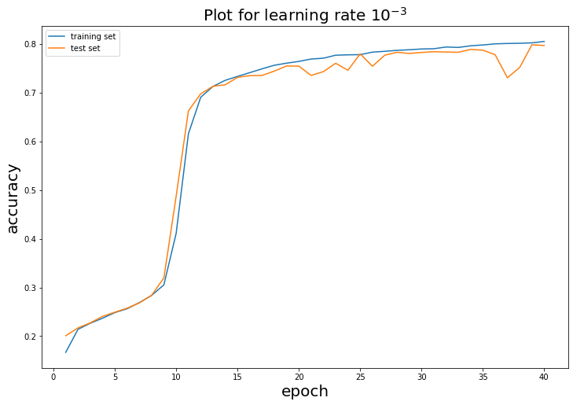

```python
plt.figure(figsize=(12,8))
plt.plot(epochs_list_40, history1.history['accuracy'], label = 'training set')
plt.plot(epochs_list_40, history1.history['val_accuracy'], label = 'test set')
plt.ylabel('accuracy', size=20)
plt.xlabel('epoch', size=20)
plt.title('Plot for learning rate $10^{-3}$', size=20)
plt.legend()
plt.show()
```

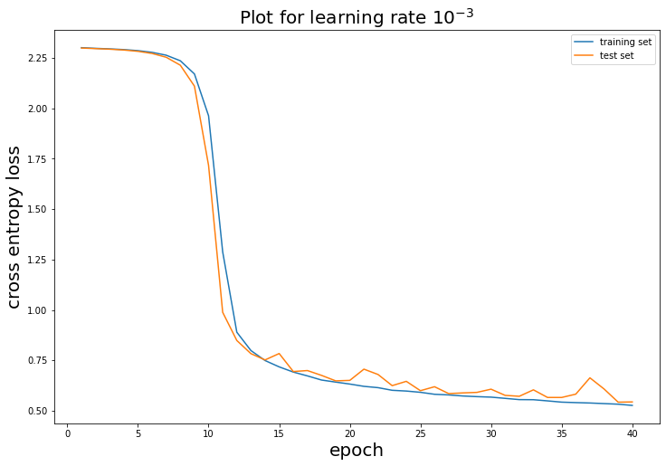

```python
plt.figure(figsize=(12,8))
plt.plot(epochs_list_40, history1.history['loss'], label = 'training set')
plt.plot(epochs_list_40, history1.history['val_loss'], label = 'test set')
plt.ylabel('cross entropy loss', size=20)
plt.xlabel('epoch', size=20)
plt.title('Plot for learning rate $10^{-3}$', size=20)
plt.legend()
plt.show()
```

The bumpiness in the above graphs for the test set is likely due to the ordering in the training dataset. If there are many observations of the same class in a sequence in the training set, the weights of the network will move too far in the direction of classifying this class.

### Task 1.2.2

I will now scan over a suitable range of the dropout probability (range [0.1, 0.9] in steps of 0.1) to find an optimal value of this dropout probability, using accuracy on the validation set as the measure of performance for this search.

```python
val_accuracies=[]
for x in np.arange(0.1, 1, 0.1):
    model = Sequential([
        Conv2D(8, (3, 3), activation=keras.layers.LeakyReLU(alpha=0.01), input_shape=(28, 28, 1)),
        Conv2D(8, (3, 3), activation=keras.layers.LeakyReLU(alpha=0.01), input_shape=(28, 28, 1)),
        Conv2D(16, (3, 3), activation=keras.layers.LeakyReLU(alpha=0.01), input_shape=(28, 28, 1)),
        Conv2D(16, (3, 3), activation=keras.layers.LeakyReLU(alpha=0.01), input_shape=(28, 28, 1)),
        MaxPooling2D((2, 2)),
        Flatten(),
        Dropout(x),
        Dense(64, activation=keras.layers.LeakyReLU(alpha=0.01), input_shape=(28, 28, 1)),
        Dense(10, activation="softmax")
    ])
    #Load the implemented model and initialize both optimizers and hyperparameters.
    model.compile(optimizer=SGD(learning_rate=0.001, momentum=0), loss="sparse_categorical_crossentropy", metrics=["accuracy"])
    #Train the model for a total of 40 epochs
    history = model.fit(x_train, y_train, epochs=40, batch_size=256, verbose=0, validation_split=0.2, shuffle=True)
    val_accuracies.append(history.history['val_accuracy'])
```

[output not shown]

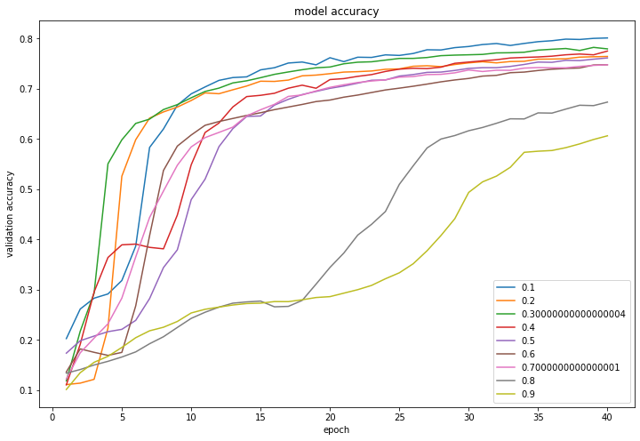

```python
plt.figure(figsize=(12,8))
for i in range(0, 9):
    plt.plot(epochs_list_40, val_accuracies[i])
plt.title('model accuracy')
plt.ylabel('validation accuracy')
plt.xlabel('epoch')
plt.legend(np.arange(0.1, 1.0, 0.1), loc='lower right')
plt.show()
```

In the graph above the accuracies increase very fast for small dropout probabilities at the beginning and then level off. However, for large dropout probabilities, the accuracies increase gradually at the beginning and then level off.

The dropout technique works by randomly reducing the number of interconnecting neurons within a neural network. We use dropout to minimise overfitting within the trained model because each neuron becomes independently sufficient, in the sense that the neurons within the layers learn weight values that are not based on the cooperation of its neighbouring neurons.

A higher dropout means less training however if you increase dropout past a certain threshold, it results in the model not being able to fit the training data properly.

I chose the optimal dropout probability to be 0.3 because with this the accuracy of the model increases rapidly at the start and levels off at a smaller epoch number. It also makes the model reach a high accuracy of 0.78 after 40 epochs. Finally, it is large enough to significantly make the computation of training the model more efficient.

```python
optimal_drop_prob = 0.3

model2 = Sequential([
        Conv2D(8, (3, 3), activation=keras.layers.LeakyReLU(alpha=0.01), input_shape=(28, 28, 1)),
        Conv2D(8, (3, 3), activation=keras.layers.LeakyReLU(alpha=0.01), input_shape=(28, 28, 1)),
        Conv2D(16, (3, 3), activation=keras.layers.LeakyReLU(alpha=0.01), input_shape=(28, 28, 1)),
        Conv2D(16, (3, 3), activation=keras.layers.LeakyReLU(alpha=0.01), input_shape=(28, 28, 1)),
        MaxPooling2D((2, 2)),
        Flatten(),
        Dropout(optimal_drop_prob),
        Dense(64, activation=keras.layers.LeakyReLU(alpha=0.01), input_shape=(28, 28, 1)),
        Dense(10, activation="softmax")
    ])
model2.compile(optimizer=SGD(learning_rate=0.001, momentum=0), loss="sparse_categorical_crossentropy", metrics=["accuracy"])
history2 = model2.fit(x_train, y_train, epochs=40, batch_size=256, validation_data= (x_test, y_test), verbose=0, shuffle=True)
```

The Faltten layer shapes the image into a one-dimensional vector.

The feature extraction section are the 4 convolution layers and the pooling layer.

The classification section is the 2 dense layers (fully connected)

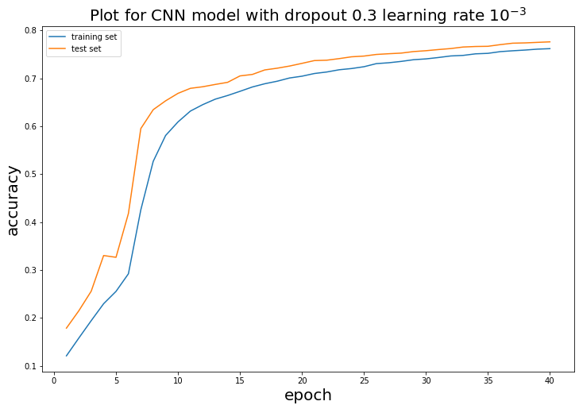

```python
plt.figure(figsize=(12,8))
plt.plot(epochs_list_40, history2.history['accuracy'], label = 'training set')
plt.plot(epochs_list_40, history2.history['val_accuracy'], label = 'test set')
plt.ylabel('accuracy', size=20)
plt.xlabel('epoch', size=20)
plt.title('Plot for CNN model with dropout 0.3 learning rate $10^{-3}$', size=20)
plt.legend()
plt.show()
```

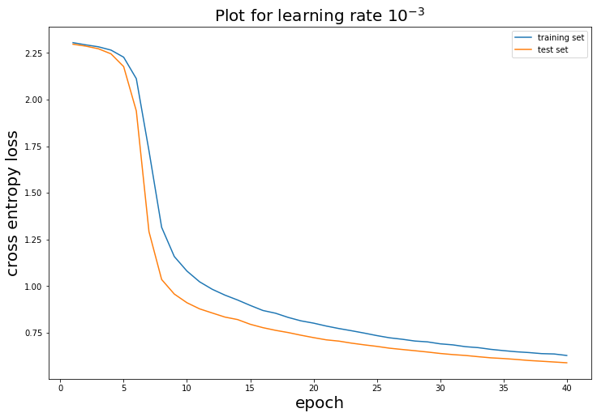

```python
plt.figure(figsize=(12,8))
plt.plot(epochs_list_40, history2.history['loss'], label = 'training set')
plt.plot(epochs_list_40, history2.history['val_loss'], label = 'test set')
plt.ylabel('cross entropy loss', size=20)
plt.xlabel('epoch', size=20)
plt.title('Plot for learning rate $10^{-3}$', size=20)
plt.legend()
plt.show()
```

```python
layer_names = model2.layers[-2].name
layer_outputs = model2.layers[-2].output
feature_map_model = tf.keras.models.Model(inputs=model2.inputs, outputs=layer_outputs)
feature_maps = feature_map_model.predict(x_test)
average_activation = np.mean(feature_maps, axis=0)
```

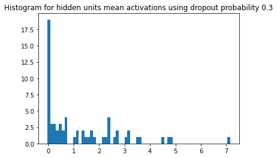

```python
plt.hist(average_activation, bins=64)
plt.title('Histogram for hidden units mean activations using dropout probability 0.3');
```

A fully connected layer occupies most of the parameters, and hence, neurons develop co-dependency amongst each other during training which curbs the power of an individual neuron. The diagram above shows that my optimal dropout probability has reduced this overfitting as many hidden units have a few zero activations. The few non-zero activations shown in the histogram are connected to the weights detecting the image's features.

### Task 1.2.3

The total number of parameters in the MLP model in Task 1.1.1 can be calculated using the following formula:

$i*h1 + \sum_{k=1}^{n-1}(h_{k}*h_{k+1})+h_{n}*o+\sum_{k=1}^{n}h_{k}+o$

where : $n$ = number of hidden layers $i$ = number of neurons in input layer \ $h_i$ = number of neurons in $i^{th}$ hidden layer \ $o$ = number of neurons in output layer

For our case $n=5$, $i=784$, $h_i=400$ (for $i$ in ${1, 2, 3, 4, 5}$) and $o = 10$. Using the above formula, my MLP in Task 1.1.1 has 959610 parameters.

```python
model2.summary()
```

```
Model: "sequential_10"
_________________________________________________________________
Layer (type)                 Output Shape              Param #
=================================================================
conv2d_40 (Conv2D)           (None, 26, 26, 8)         80
_________________________________________________________________
conv2d_41 (Conv2D)           (None, 24, 24, 8)         584
_________________________________________________________________
conv2d_42 (Conv2D)           (None, 22, 22, 16)        1168
_________________________________________________________________
conv2d_43 (Conv2D)           (None, 20, 20, 16)        2320
_________________________________________________________________
max_pooling2d_10 (MaxPooling (None, 10, 10, 16)        0
_________________________________________________________________
flatten_10 (Flatten)         (None, 1600)              0
_________________________________________________________________
dropout_9 (Dropout)          (None, 1600)              0
_________________________________________________________________
dense_20 (Dense)             (None, 64)                102464
_________________________________________________________________
dense_21 (Dense)             (None, 10)                650
=================================================================
Total params: 107,266
Trainable params: 107,266
Non-trainable params: 0
_________________________________________________________________
```

The CNN model with dropout has 107266 total parameters which are nearly 9 times less than for my MLP model. The two models achieve similar accuracy after 40 epochs (although MLP model accuracies are around 3% higher for both training and test sets) and hence our CNN dropout model is much more computational efficient due to less number of parameters.

MLP has the characteristic of fully connected layers. There is redundancy in such high dimensions of the model. Since CNN can account for local connectivity (each filter is panned around the entire image according to a certain size and stride) allows the filter to find and match patterns anywhere in the image. This makes CNN weights smaller and shared and easier to train than MLP.

Can account for local connectivity (each filter is panned around the entire image according to a certain size and stride, allowing the filter to find and match patterns no matter where the pattern is located in a given image). This model can go deeper too than MLP as layers are sparsely connected.

### Task 1.2.4

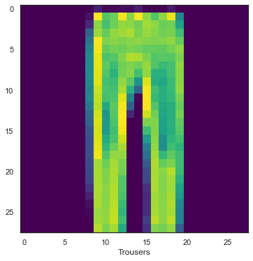

```python
label_names = ['T-shirt/top','Trousers','Pullover','Dress','Coat','Sandal','Shirt','Sneaker','Bag','Ankle boot']

(x_train, y_train), (x_test, y_test) = tf.keras.datasets.fashion_mnist.load_data()
x_train = x_train.astype('float32') / 255
x_test = x_test.astype('float32') / 255

plt.figure(figsize=(6,6))
x = np.random.randint(10000)
plt.imshow(x_test[x], cmap='viridis')
plt.xlabel(label_names[y_test[x]])
plt.show()
```

```python
# Extract model layer outputs
layer_outputs = [layer.output for layer in model2.layers[:4]]

# Rather then a model with a single output, we are going to make a model to display the feature maps
activation_model = tf.keras.models.Model(inputs=model2.input, outputs=layer_outputs)
```

```python
x_test = x_test.reshape((x_test.shape + (1,)))
activations = activation_model.predict(x_test)
```

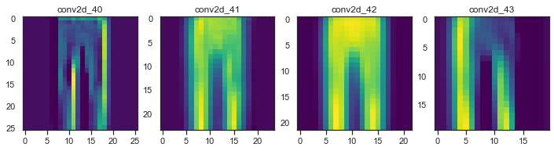

```python
fig, axes = plt.subplots(1,4, figsize=(12,8))

layer_names = []
for layer in model2.layers[:4]:
    layer_names.append(layer.name)

for i in range(4):
    column = i%4
    ax = axes[column]
    cur_layer = activations[i]
    ax.matshow(cur_layer[x, :, :, 7], cmap='viridis')
    ax.xaxis.set_ticks_position('bottom')
    ax.set_title(layer_names[i])
```

In the feature map from the first convolutional layer (left plot), the image highlights the right outline of the trouser and the left inseam of the trouser. This layer retains most of the information of the original image.

The feature map image from the second convolutional layer seems to be looking at the whole trouser.

The feature map from the third layer encodes similar features to the third layer but with more focus on the trouser part which fits the hips and the part which fits the chin.

The feature map image from the fourth layer activations is looking deeper and encodes higher-level concepts. It is looking at the almost opposite part of the trouser than what the first layer looked at. Now the layer is looking at the left part of the trouser and especially the left trouser outline and left inseam outline.

You can notice that the image of each convolution layer is a little more zoomed in. So as you go deeper into the convolution layers, each feature map is focusing on a certain part of the original image.

As we go deeper into the layers, the activations become increasingly abstract and less visually interpretable. Higher presentations carry increasingly less information about the visual contents of the image, and increasingly more information related to the class of the image.

# Task 2: Unsupervised learning ^

## 2.1 Dimensionality reduction and clustering of a subset of the Fashion-MNIST image data ^

### Task 2.1.1

```python
def load_data():
    (x_train, y_train), (x_test, y_test) = tf.keras.datasets.fashion_mnist.load_data()
    x_train = x_train.astype('float32') / 255
    x_test = x_test.astype('float32') / 255
    # convert labels to categorical samples
    y_train = tf.keras.utils.to_categorical(y_train, num_classes=10)
    y_test = tf.keras.utils.to_categorical(y_test, num_classes=10)
    return ((x_train, y_train), (x_test, y_test))

(x_train, y_train), (x_test, y_test) = load_data()
x_train = x_train.reshape((-1, 28**2))
x_test = x_test.reshape((-1, 28**2))
```

```python
def standardise(X):
    mu = np.mean(X, axis=0)
    std = np.std(X, axis=0)
    std_filled = std.copy()
    std_filled[std==0] = 1.
    Xbar = ((X-mu)/std_filled)
    return Xbar
```

```python
x_train_1000 = standardise(x_train[:1000])
y_train_1000 = y_train[:1000]
```

```python
def pca_function(X,k):

    # create covariance matrix S
    C = 1.0/(len(X)-1) * np.dot(X.T, X)

    # compute eigenvalues and eigenvectors using the eigsh scipy function
    eigenvalues, eigenvectors = linalg.eigsh(C, k, which="LM", return_eigenvectors=True)

    # sorting the eigenvectors and eigenvalues from largest to smallest eigenvalue
    sorted_index = np.argsort(eigenvalues)[::-1]
    eigenvalues=eigenvalues[sorted_index]
    eigenvectors=eigenvectors[:,sorted_index ]

    # transform our data
    X_pca = X.dot(eigenvectors)

    return X_pca, eigenvectors, eigenvalues

X_pca, eigenvectors, eigenvalues = pca_function(x_train_1000,784)
```

### Task 2.1.2

```python
# choose our number of principle components
k = 25

# compute the projection, the eigenvector and eigenvalues from our function
X_pca, eigenvectors, eigenvalues = pca_function(x_train_1000,k)
```

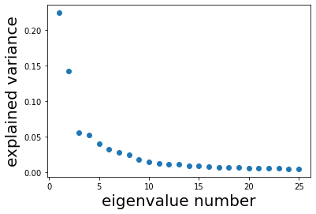

```python
C = 1.0/(len(x_train_1000)-1) * np.dot(x_train_1000.T, x_train_1000)
all_eigenvalues, _ = np.linalg.eig(C)
total_variance = abs(all_eigenvalues.sum())

explained_variances = eigenvalues /  total_variance
plt.plot(np.arange(1, 26, 1), explained_variances, 'o')
plt.ylabel('explained variance', size=20)
plt.xlabel('eigenvalue number', size=20)
plt.show()
```

### Task 2.1.3

```python
# choose our number of principle components
k = 2

# compute the projection, the eigenvector and eigenvalues from our function
X_pca, eigenvectors, eigenvalues = pca_function(x_train_1000,k)
```

```python
index=[]
for i in range(1000):
    for j in range(10):
        if y_train_1000[i][j]==1:
            index.append(j)
```

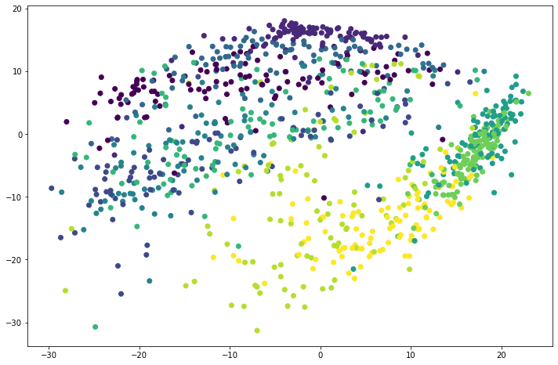

```python
plt.figure(figsize=(12,8))
plt.scatter(X_pca[:,0],X_pca[:,1], c= index)
plt.show()
```

From the plot above. We can see that there exist two clusters and potentially even a third cluster. The green and yellow clustering are obvious. Whereas points with the colours close to the shades of blue are very much scattered and not separable. I think reducing our data to 2 dimensional does retain a lot of the structure and information of the data but isn't perfect. Some classes are almost inseparable from some other classes in dimensionality reduction to two dimensions.

### Task 2.1.4

```python
n_samples, n_features = X_pca.shape

# number of clusters k
k = 10

# labels: assign every sample to a cluster at random
labels = np.random.randint(low=0, high=10, size=n_samples) # randomly generate labels
X_labels = np.append(X_pca, labels.reshape(-1,1), axis=1)
centroids = np.zeros((k, n_features))

# computing the centroids of each of the k clusters
for i in range(k):
    centroids[i] = np.mean([x for x in X_labels if x[-1]==i], axis=0)[0:2]
```

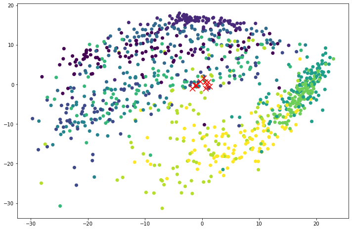

```python
plt.figure(figsize=(12,8))
plt.scatter(X_pca[:,0],X_pca[:,1], c= index)
plt.scatter(centroids[:, 0], centroids[:, 1], c='red', marker='x', s=120); #initial centriods
plt.scatter
plt.show()
```

```python
def k_means(X_pca, k, max_iter = 15, difference = 0):
    n_samples, n_features = X_pca.shape

    # labels: assign every sample to a cluster at random
    labels = np.random.randint(low=0, high=10, size=n_samples) # randomly generate labels
    X_labels = np.append(X_pca, labels.reshape(-1,1), axis=1)
    centroids = np.zeros((k, n_features))

    # computing the centroids of each of the k clusters
    for i in range(k):
        centroids[i] = np.mean([x for x in X_labels if x[-1]==i], axis=0)[0:2]

    new_labels = np.zeros(len(X_pca))

    # k-means algorithm
    for i in range(max_iter):
        #print('Iteration:', i)
        # distances: between data points and centroids
        distances = np.array([np.linalg.norm(X_pca - c, axis=1) for c in centroids])
        # new_labels: computed by finding centroid with minimal distance
        new_labels = np.argmin(distances, axis=0)

        if (labels==new_labels).all():
            # labels unchanged
            labels = new_labels
            #print('Labels unchanged! Terminating k-means.')
            break
        else:
            # labels changed
            # difference: percentage of changed labels
            difference = np.mean(labels!=new_labels)
            #print('%4f%% labels changed' % (difference * 100))
            labels = new_labels
            for c in range(k):
                # update centroids by taking the mean over associated data points
                if (labels == c).any():
                    centroids[c] = np.mean(X_pca[labels==c], axis=0)


    return labels, centroids
```

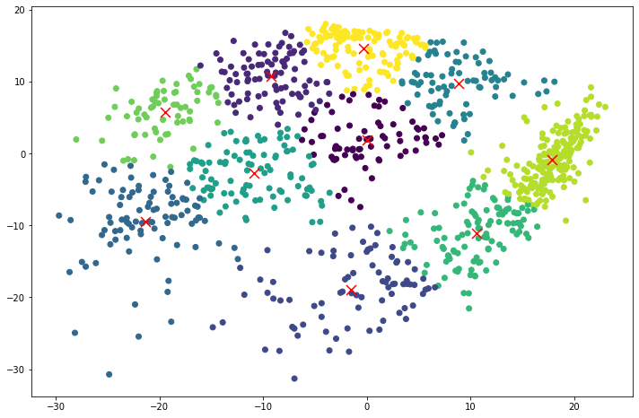

```python
plt.figure(figsize=(12,8))
labels, centroids = k_means(X_pca, 10)
plt.scatter(X_pca[:,0],X_pca[:,1], c= labels)
plt.scatter(centroids[:, 0], centroids[:, 1], c='red', marker='x', s=120);
plt.show()
```

In the above diagram, I used my K-means algorithm with 10 clusters to verify visually that the centroids and clusters are implemented correctly in the k-means function.

Below I am optimising k-means clustering by computing the distance between every point and only its corresponding cluster's centroid as suggested in lecture notes.

```python
within_distances_ks = []
for k in range(2, 11):
    labels, centroids = k_means(X_pca, k)
    total = 0
    for index, label in enumerate(labels):
        total += np.sum(np.square(X_pca[index] - centroids[label]))
    within_distances_ks.append(total)
```

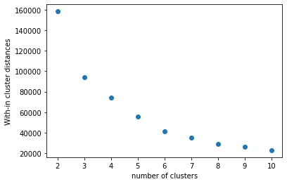

```python
plt.plot(np.arange(2, 11, 1), within_distances_ks, 'o')
plt.ylabel('With-in cluster distances', size=10)
plt.xlabel('number of clusters', size=10)
plt.show()
```

## 2.2 Clustering of the feature matrix ^

### Task 2.2.1

```python
F = np.load('dolphins_F_62x32(1).npy') #read in the feature matrix
```

```python
def pairwise_distances(points):
    '''
    Args:
        points: A numpy array of points having the shape (N, D),
          where N is the number of points and D is the number of features.
    Returns:
        A numpy array with shape (N, N) such that the element (i, j) is the computed
        distance between i-th point and j-th point in X.
    '''
    N, D = points.shape
    distance = np.empty((N, N))

    # distance matrix will be symmetric, so avoid redundant computations.
    for i in range(N):
        distance[i, i] = 0
        for j in range(i + 1, N):
            d = np.sqrt(np.power(points[i, :] - points[j, :], 2).sum())
            distance[i, j] = d
            distance[j, i] = d

    return distance
```

```python
d = pairwise_distances(F)
```

```python
def average_linkage(distances, cluster_assignment, i, j):
    """
    This function computes the average linkage value between two clusters.
    Args:
      distances: A numpy array of pair-wise distances for the given points.
      cluster_assignment: A 1-D numpy array that assigns a cluster id for every point.
      i: the first cluster id.
      j: the second cluster id.
    Returns:
      The average distance between the two given clusters.
    """
    # Select the point indices of the first cluster.
    points_i = np.argwhere(cluster_assignment == i)
    # Select the point indices of the second cluster.
    points_j = np.argwhere(cluster_assignment == j)
    # Form a cartesian product between the indices in i and indices in j.
    pairs = np.array([[element_i.item(), element_j.item()]  for element_i in points_i for element_j in points_j])
    # Select the pair distances between the points in the two clusters from the distances matrix.
    pairs_distance = distances[pairs[:, 0], pairs[:, 1]]
    # Return the average
    return pairs_distance.mean()
```

```python
def hierarchical_clustering(points, distances, linkage):
    """
    The hierarchical clustering algorithm start with every point as a single cluster and
    each iteration merges two clusters into one. We may wish to store all the
    intermediate clustering results with respect to the number of clusters left.

    Args:
     points: A numpy array of points having the shape (N, D),
          where N is the number of points and D is the number of features.
     distances: A numpy array with shape (N, N) such that the element (i, j) is the computed
        distance between i-th point and j-th point in X.
     linkage: A linkage function from the above to call to compute the linkage values between two clusters.

    Returns:
     A numpy array of shape (N, N) of which each row stores the clustering assignment at each level.
     The first row, i.e. a[0, :], represents the highest level of clustering where all columns have the same index value.
     The second row, i.e. a[1, :], represents all the points assigned into two cluster indices.
     The last row, i.e. a[N - 1, :], represents the points assigned into N - 1 cluster indices.
    """
    N, D = points.shape
    assignments = np.zeros((N, N))

    # Begin with every point is its own cluster
    current_assignment = np.arange(N)

    # The id to be assigned for the next merged cluster
    next_cluster_id = N

    # Begin from level (N - 1) to level 1
    for level in range(N - 1, 0, -1):
        cluster_ids = np.unique(current_assignment)

        min_d = np.inf

        # Initialize the cluster ids to be merged in this iteration.
        cluster_a, cluster_b = (-1, -1)

        # Now find the two clusters that have the minimum distance in between.
        for i in range(cluster_ids.size):
            for j in range(i + 1, cluster_ids.size):
                cluster_i = cluster_ids[i]
                cluster_j = cluster_ids[j]
                d = linkage(distances, current_assignment, cluster_i, cluster_j)
                if d < min_d:
                    min_d = d
                    cluster_a, cluster_b = (cluster_i, cluster_j)


        # Merge the two clusters
        current_assignment[(current_assignment == cluster_a) | (current_assignment == cluster_b)] = next_cluster_id
        next_cluster_id += 1
        # Store the current cluster assignment into the assignments array.
        assignments[level, :] = current_assignment

    return assignments
```

```python
dendogram = hierarchical_clustering(F, d, average_linkage)
```

```python
def split_cluster(seq):
    split_clusters_list=[]
    for x in set(seq):
        cluster_x = []
        for y in range(len(seq)):
            if seq[y] == x:
                cluster_x.append(y)
        split_clusters_list.append(cluster_x)
    return split_clusters_list

fine_to_coarse = []
for i in range(dendogram.shape[0]):
    reverse_row_index = dendogram.shape[0] - (i + 1) # since finest to coarsest
    fine_to_coarse.append(split_cluster(dendogram[reverse_row_index, :]))
```

```python
#show my clustering work
print(fine_to_coarse[0], '\n ^^^^ 1st finest clusters \n')
print(fine_to_coarse[1], '\n ^^^^ 2nd finest clusters \n')
print(fine_to_coarse[2], '\n ^^^^ 3rd finest clusters \n')
print(' .... \n .... \n .... \n')
print(fine_to_coarse[-1], '\n ^^^^ coarsest clusters  \n')
```

```
[[0], [1], [2], [3], [4], [5], [6], [7], [8], [9], [10], [11], [12], [13], [14], [15], [16], [17], [18], [19], [20], [21], [23], [24], [25], [26], [27], [28], [29], [30], [32], [33], [34], [35], [36], [37], [38], [39], [40], [41], [42], [43], [44], [45], [46], [47], [48], [49], [50], [51], [52], [53…
 ^^^^ 1st finest clusters

[[0], [1], [2], [3], [5], [6], [7], [8], [9], [10], [12], [13], [14], [15], [16], [17], [18], [19], [20], [21], [23], [24], [25], [26], [27], [28], [29], [30], [32], [33], [34], [35], [36], [37], [38], [39], [40], [41], [42], [43], [44], [45], [46], [47], [48], [49], [50], [51], [52], [53], [54], [5…
 ^^^^ 2nd finest clusters

[[0], [1], [2], [3], [5], [6], [7], [8], [10], [12], [14], [15], [16], [17], [18], [19], [20], [21], [23], [24], [25], [26], [27], [28], [29], [30], [32], [33], [34], [35], [36], [37], [38], [39], [40], [41], [42], [43], [44], [45], [46], [47], [48], [49], [50], [51], [52], [53], [54], [55], [56], […
 ^^^^ 3rd finest clusters

 ....
 ....
 ....

[[0, 1, 2, 3, 4, 5, 6, 7, 8, 9, 10, 11, 12, 13, 14, 15, 16, 17, 18, 19, 20, 21, 22, 23, 24, 25, 26, 27, 28, 29, 30, 31, 32, 33, 34, 35, 36, 37, 38, 39, 40, 41, 42, 43, 44, 45, 46, 47, 48, 49, 50, 51, 52, 53, 54, 55, 56, 57, 58, 59, 60, 61]]
 ^^^^ coarsest clusters
```

I didn't print the rest of the clusters for redundancy and conciseness reasons.

### Task 2.2.2

Silhouette coefficients isn't defined when there is just one cluster as d2 cant be worked out for any sample. Hence, below I remove such clusters arrangments.

```python
new_fine_to_coarse=fine_to_coarse[:60]
```

By convention silhouette coefficient for singleton point clusters is 0. Since d1 is 0. A problem with the silhouette is that it is not well defined for 1 element clusters. Because the average distance to other cluster members then is an average over 0 values and thus undefined.

```python
def silhouette_score_curr_level(clustering, F):
    silhouette_coeffs_curr=[]
    for list_index in range(len(clustering)):
        for point_index in clustering[list_index]:

            if len(clustering[list_index])==1:
                silhouette_coeffs_curr.append(0)
            else:
                d2=[]
                for cluster in clustering:
                    if point_index in cluster:
                        d1 = np.mean([np.sum(np.square(F[point_index] - F[other_point_index]))**0.5 for other_point_index in cluster if point_index != other_point_index])
                    else:
                        d2.append(np.mean([np.sum(np.square(F[point_index] - F[other_point_index1]))**0.5 for other_point_index1 in cluster]))
                d2=min(d2)
                silhouette_coeffs_curr.append((d2-d1)/max(d2, d1))
    return np.mean(silhouette_coeffs_curr)

silhouette_score_all_levels=[]
for level in range(len(new_fine_to_coarse)):
    silhouette_score_all_levels.append(silhouette_score_curr_level(new_fine_to_coarse[level], F))
```

```python
print('The maximum silhouette score is:',max(silhouette_score_all_levels))
print('The maximum silhouette score is achieved when number of clusters is:', len(new_fine_to_coarse[np.argmax(silhouette_score_all_levels)]))
```

```
The maximum silhouette score is: 0.29081215536809146
The maximum silhouette score is achieved when number of clusters is: 2
```

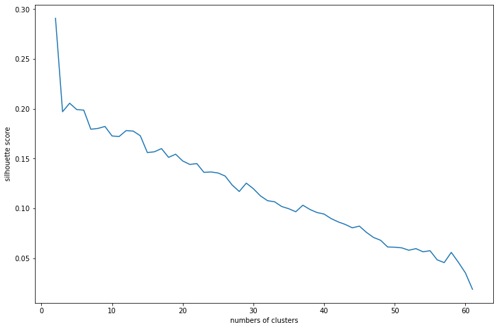

```python
plt.figure(figsize=(12,8))
plt.plot(range(2, 62), silhouette_score_all_levels[::-1])
plt.xlabel('numbers of clusters')
plt.ylabel('silhouette score');
```

The Silhouette Score is a measure of the quality of clustering and is defined as the mean Silhouette Coefficient over all samples. The higher the silhouette score the better the quality of clustering in this measure.

I used the Sklearn silhouette score function to verify that the above graph is correct. Hence the optimal K is when the maximum silhouette score is achieved, which means optimal k is 2.

## 2.3 Graph-based analysis ^

### Task 2.3.1

```python
A = np.load('dolphins_A_62x62(1).npy') #read in the adjacency matrix
```

```python
import networkx as nx
G = nx.Graph(A)
```

Compute the normalized Laplacian of the dolphin network

```python
# define diagonal matrix of node degrees
weighted_degree = A.sum(axis=1)

# create diagonal matrix of degree
D = np.diag(weighted_degree)

# define Laplacian
L = D-A
```

```python
# computing inverse square root vector of degree
weighted_degree_sqrt = 1.0 / np.sqrt(weighted_degree)

# set a diagonal matrix of the inverse square root of degree
D_inv_sqrt = np.diag(weighted_degree_sqrt)

# define the normalised Laplacian
L_norm = np.eye(A.shape[0]) - D_inv_sqrt.dot(A.dot(D_inv_sqrt))
```

```python
# return the smallest magnitude eigenvectors and eigenvalues
eigenvals, eigenvecs = linalg.eigsh(L_norm, 2, which="SM", return_eigenvectors=True)
```

```python
# printing the eigenvalues
print('The first smallest eigenalue is: {}'.format(eigenvals[0]))
print('The second smallest eigenalue is: {}'.format(eigenvals[1]))
```

```
The first smallest eigenalue is: -2.761666221227921e-16
The second smallest eigenalue is: 0.03952455375743408
```

The first smallest eigenvalue is almost zero. We can assume its non-zero nature is due to a rounding error by my computer. Hence we can view this eigenvalue to be trivially zero. As explained in lecture notes week 10 page 142 lecture notes, this eigenvalue cannot be the solution when looking to minimise cost. Hence our minimal cost is achieved by choosing the second smallest eigenvalue, which is non-zero.

The quality of the bipartition is directly related to the second smallest eigenvalue, which is also called the algebraic connectivity of the graph. My second smallest eigenvector is small enough for me to assume that the graph isn't well connected hence cost of splitting the graph is low (there exists a good bipartition of the graph by the second eigenvector).

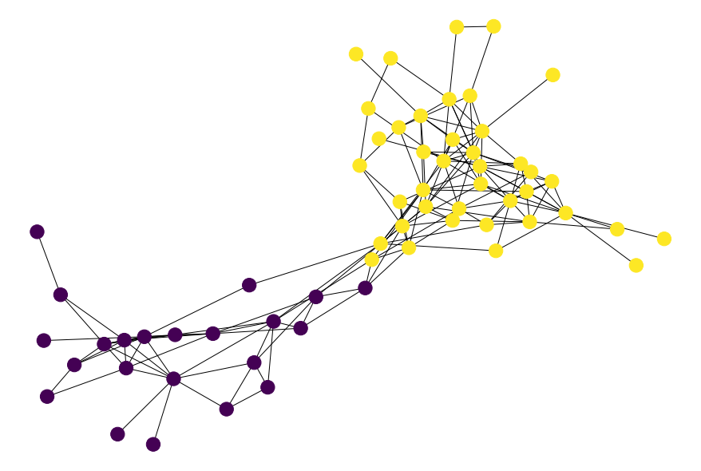

```python
# define a partition and binarize the negative and positive eigenvector values
spectral_partition = eigenvecs[:,1] # 2nd eigenvector
spectral_partition[spectral_partition<0] = 0
spectral_partition[spectral_partition>0] = 1

plt.figure(figsize=(12,8))
# draw the spectral partition
nx.draw(G, node_color=spectral_partition)
```

Above is the spectral partition of the graph produced by the dolphin data into two sets of nodes.

### Task 2.3.2

```python
#Page Rank centrality
alpha=0.85 #from notes
N = 62 #62 dolphins
centrality_pagerank = np.linalg.inv(np.eye(A.shape[0]) - alpha * A @ np.linalg.inv(D)) @ ((1-alpha)*np.ones(N))/N
```

```python
#degree centrality
# compute the degree of the adjacency
degree = A.sum(axis=1)
```

```python
#eigenvector centrality
# compute the eigenvector associated with the largest eigenvalue
eigenvalue, eigenvector = linalg.eigsh(A, 1, which="LM", return_eigenvectors=True)
```

```python
dophin_names = pd.read_csv('dolphin_names.csv')
dophin_names = dophin_names.to_numpy()
```

```python
d1 = {'Node number': dophin_names[:,0 ], 'Dolphin Name': dophin_names[:,1 ], 'PageRank centrality':centrality_pagerank, 'Degree centrality':degree, 'Eigenvector centrality':eigenvector.reshape((62,))}
df1 = pd.DataFrame(data=d1)
df1.style.hide_index()
```

| Node number | Dolphin Name | PageRank centrality | Degree centrality | Eigenvector centrality |
| --- | --- | --- | --- | --- |
| 0 | Beak | 0.016965 | 6.000000 | 0.128504 |
| 1 | Beescratch | 0.024651 | 8.000000 | 0.042076 |
| 2 | Bumper | 0.013338 | 4.000000 | 0.039757 |
| 3 | CCL | 0.009629 | 3.000000 | 0.079335 |
| 4 | Cross | 0.005080 | 1.000000 | 0.029287 |
| 5 | DN16 | 0.014428 | 4.000000 | 0.006559 |
| 6 | DN21 | 0.020054 | 6.000000 | 0.012191 |
| 7 | DN63 | 0.015643 | 5.000000 | 0.042901 |
| 8 | Double | 0.017098 | 6.000000 | 0.143102 |
| 9 | Feather | 0.023458 | 7.000000 | 0.012197 |
| 10 | Fish | 0.015108 | 5.000000 | 0.075253 |
| 11 | Five | 0.005080 | 1.000000 | 0.029287 |
| 12 | Fork | 0.004835 | 1.000000 | 0.039076 |
| 13 | Gallatin | 0.026157 | 8.000000 | 0.015005 |
| 14 | Grin | 0.032144 | 12.000000 | 0.315783 |
| 15 | Haecksel | 0.019883 | 7.000000 | 0.164176 |
| 16 | Hook | 0.016627 | 6.000000 | 0.207994 |
| 17 | Jet | 0.031728 | 9.000000 | 0.017512 |
| 18 | Jonah | 0.019396 | 7.000000 | 0.202495 |
| 19 | Knit | 0.012928 | 4.000000 | 0.020675 |
| 20 | Kringel | 0.024641 | 9.000000 | 0.184477 |
| 21 | MN105 | 0.016939 | 6.000000 | 0.207351 |
| 22 | MN23 | 0.005416 | 1.000000 | 0.002434 |
| 23 | MN60 | 0.009863 | 3.000000 | 0.087362 |
| 24 | MN83 | 0.016906 | 6.000000 | 0.193214 |
| 25 | Mus | 0.011504 | 3.000000 | 0.005946 |
| 26 | Notch | 0.011210 | 3.000000 | 0.008944 |
| 27 | Number1 | 0.017130 | 5.000000 | 0.016317 |
| 28 | Oscar | 0.014846 | 5.000000 | 0.068224 |
| 29 | Patchback | 0.026459 | 9.000000 | 0.211763 |
| 30 | PL | 0.015302 | 5.000000 | 0.040747 |
| 31 | Quasi | 0.005416 | 1.000000 | 0.002434 |
| 32 | Ripplefluke | 0.013309 | 3.000000 | 0.003856 |
| 33 | Scabs | 0.028423 | 10.000000 | 0.281099 |
| 34 | Shmuddel | 0.015920 | 5.000000 | 0.138828 |
| 35 | SMN5 | 0.004918 | 1.000000 | 0.029438 |
| 36 | SN100 | 0.020613 | 7.000000 | 0.132762 |
| 37 | SN4 | 0.029875 | 11.000000 | 0.300562 |
| 38 | SN63 | 0.023939 | 8.000000 | 0.196618 |
| 39 | SN89 | 0.007765 | 2.000000 | 0.020871 |
| 40 | SN9 | 0.021966 | 8.000000 | 0.207872 |
| 41 | SN90 | 0.016138 | 5.000000 | 0.015244 |
| 42 | SN96 | 0.017619 | 6.000000 | 0.080950 |
| 43 | Stripes | 0.021691 | 7.000000 | 0.190339 |
| 44 | Thumper | 0.012831 | 4.000000 | 0.077802 |
| 45 | Topless | 0.029514 | 11.000000 | 0.285005 |
| 46 | TR120 | 0.008826 | 2.000000 | 0.029717 |
| 47 | TR77 | 0.017340 | 6.000000 | 0.080371 |
| 48 | TR82 | 0.005262 | 1.000000 | 0.002415 |
| 49 | TR88 | 0.008877 | 2.000000 | 0.023430 |
| 50 | TR99 | 0.019232 | 7.000000 | 0.217692 |
| 51 | Trigger | 0.031299 | 10.000000 | 0.210682 |
| 52 | TSN103 | 0.012073 | 4.000000 | 0.129564 |
| 53 | TSN83 | 0.008181 | 2.000000 | 0.033687 |
| 54 | Upbang | 0.021651 | 7.000000 | 0.023002 |
| 55 | Vau | 0.007494 | 2.000000 | 0.052110 |
| 56 | Wave | 0.008326 | 2.000000 | 0.002607 |
| 57 | Web | 0.030095 | 9.000000 | 0.017376 |
| 58 | Whitetip | 0.004963 | 1.000000 | 0.027332 |
| 59 | Zap | 0.014768 | 5.000000 | 0.111819 |
| 60 | Zig | 0.006190 | 1.000000 | 0.000536 |
| 61 | Zipfel | 0.011039 | 3.000000 | 0.051991 |

From the above table printout and it is clear that node 14 (dolphin with the name Grin) is the most central as this node has the largest magnitude of PageRank centrality, degree centrality and eigenvector centrality values.

```python
top_10_degree_idx = ((np.argsort(degree)[-10:])[::-1]).tolist()
top_10_eigen_idx = ((np.argsort(eigenvector.reshape((62,)))[-10:])[::-1]).tolist()
top_10_pagerank_idx = ((np.argsort(centrality_pagerank)[-10:])[::-1]).tolist()
names=dophin_names[:,1 ]
```

```python
d2 = {'Top 10 PageRank central dolphins': names[top_10_pagerank_idx], 'Top 10 degree central dolphins': names[top_10_degree_idx], 'Top 10 eigenvector central dolphins':names[top_10_eigen_idx]}
df2 = pd.DataFrame(data=d2)
print('This table orders the dolphins from most to least central according to each centrality measure for the top 10 dolphins in each category.')
df2.style.hide_index()
```

```
This table orders the dolphins from most to least central according to each centrality measure for the top 10 dolphins in each category.
```

| Top 10 PageRank central dolphins | Top 10 degree central dolphins | Top 10 eigenvector central dolphins |
| --- | --- | --- |
| Grin | Grin | Grin |
| Jet | Topless | SN4 |
| Trigger | SN4 | Topless |
| Web | Scabs | Scabs |
| SN4 | Trigger | TR99 |
| Topless | Jet | Patchback |
| Scabs | Web | Trigger |
| Patchback | Patchback | Hook |
| Gallatin | Kringel | SN9 |
| Beescratch | Gallatin | MN105 |

From the above table, we can see that Grin, SN4, Topless, Scabs and Trigger to name a few are dolphins with the highest centrality across all three centrality measures.

In Lusseau et al, according to the dendrogram (Fig 4), the dolphins seems to be clustered in 3 groups. Trigger seems to have a central position between groups two and three according to the sociogram (Fig 5) in the paper. Topless is a central individual in group 2, which has 7 dolphins. The dendrogram tells us that Grin, SN4, Topless, Scabs and Trigger belong to the same group 2. Group 2 is generally well connected for each individual within (as it contains many central dolphins) and hence relatively more social. Scabs is known to hold the central position in the female group.

It makes sense that Grin, Scabs, Topless and SN4 score highly on the degree centrality because these dolphins are part of a group 2 with many members in the dendrogram (Fig. 4 in the paper) and also from the sociogram (Fig.5), we can see they have a lot of connections to other dolphins.

Grin and Scabs have high eigenvector centrality because they are connected to other highly central dolphins such as SN4 and to some degree Hook in the sociogram. This means that Grin and Scabs have connections with many other popular dolphins.

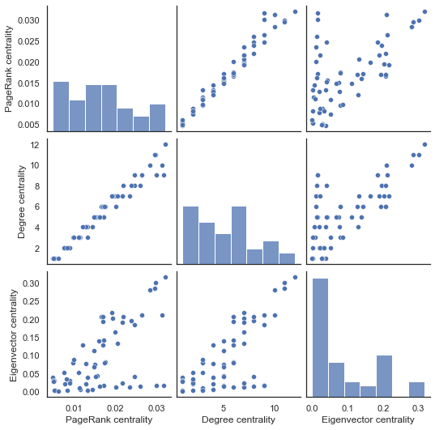

```python
sns.set(style='white')
data = {'PageRank centrality':centrality_pagerank, 'Degree centrality':degree, 'Eigenvector centrality':eigenvector.reshape((62,))}
df = pd.DataFrame(data)

g = sns.pairplot(df)
plt.show()
```

We can see that the degree centrality measure is highly positively correlated with PageRank centrality (this is because the PageRank centrality calculation uses the degree matrix). However, degree centrality is correlated with Eigenvector centrality, although not as strongly the combination in the previous sentence.

The centrality rankings differ between the 3 centrality measures because they each measure the importance of a node from a different perspective and further provides relevant analytical information about the graph and its nodes. In Eigenvector centrality, higher importance is given to nodes that are themselves connected to other highly central nodes whereas in Degree centrality higher importance is given to nodes that are connected to a large number of other nodes. Finally, in PageRank centrality, nodes, where many searches will reside with higher probability, are given high importance. Therefore PageRank is more useful with directed graphs unlike our undirected graph.

References:

[1] https://towardsdatascience.com/derivative-of-the-softmax-function-and-the-categorical-cross-entropy-loss-ffceefc081d1

[2] https://towardsdatascience.com/batch-mini-batch-stochastic-gradient-descent-7a62ecba642a

[3] https://towardsdatascience.com/deriving-backpropagation-with-cross-entropy-loss-d24811edeaf9